# A network approach to ResPOnsE COVID-19 dataset

## H5

- institutional confidence -> support prime minister [positive]
- institutional confidence -> support regional system [positive]
- institutional confidence -> compliance [**null**]
- institutional confidence -> willingness to restrict [**null**]
- support prime minister -> compliance [**null**]
- support prime minister -> risk perception [**null**]
- support prime minister -> willingness to restrict [**null**]
- support regional system -> willingness to restrict [**null**]
- support regional system -> risk perception [**negative**]
- support regional system -> compliance [**null**]
- risk perception -> compliance [**null**]
- risk perception -> willingness to restrict [**null**]
- L/R self-placement -> institutional confidence [negative]
- L/R self-placement -> support prime minister [negative]

Finally, predictor of compliance in the completed network are (decreasing order):

- Willingness to restrict [positive]
- Age [positive]
- Attitude toward science [positive]
- Horizontal trust [negative]
- Sex [0 = women]

Hence, *H5* is confirmed. An enlarged picture of ResPOnsE COVID-19 give us a different account of the variables influencing compliance to preventive behaviors. First, some of the variable chosen in the SEM of Figure 1 resulted marginal and peripheral in the full *mgm* network. Second, many of the estimated relationship of that model do not appear in the network representation of ResPOnsE. This means that their statistical significance vanish after controlling for the influence of other variables. Third, the full network gave us a deeper insight at the list of the valid and important predictor of compliance. Within this list, willingness to restrict personal freedom emerged as the most important attitude influencing the behavioral node. Also the demographic variables sex and age strongly influence compliance, and their impact could be calculated only by choosing *mgm* as the estimation procedure. Finally, attitudes toward science are another addition to this list, since they were not present in the model of Figure 1, but indicated as relevant in the network model.

# Limitation

Here i mention the two main limitations of this report. First, compliance is more a constant than a variable in W1 of ResPOnsE dataset (see below, additional material, descriptives). This is a serious shortcoming that would deficit any predictive analysis on this data. Second, community detection algorithm was probably uncapable of detecting the true number of communities. This function requires 1000 iterations to be computed with stable results. However, due to the large sample size, the huge amount of nodes, and the limited computational power I have at disposal I had to run 100 iterations only. I had to stop the full cycle after 30 hours of processing. I have to find a way to compute this function renting an R server.

# Additional material

This report and all the analyeses are fully reproducible. This is the link to my GitHub repositorty:

https://github.com/ArtBert96/response

The repository is organized with the IPO protocol. By running on Rstudio all the syntax file in the “Processing” folder, the machine uses the data in “Input” to produce all graphs and images in “Output”. In the section below I only add descriptives and summary information about the factor analysis.

## Factor analysis

Eigen values of Principal Component Analysis performed on items of the same battery.

| **Index** | **Eigenvalue comp.1** | **Eigenvalue comp.2** |
| --- | --- | --- |
| Compliance to preventive behaviors | 1.6 | 0.7 |
| Willingness to restrict freedoms | 1.3 | 0.5 |
| Institutional trust | 1.3 | 0.6 |
| Risk perception | 1.3 | 0.7 |
| Collectivism | 1.3 | 0.6 |
| Support for regional system | 1.3 | 0.7 |
| Attitudes toward science | 1.4 | 0.8 |
| Attitudes toward medicine | 1.4 | 0.8 |

Cronbach’s Alpha

| **Index** | **Cronbach’s Alpha** |
| --- | --- |
| Compliance to preventive behaviors | 0.8 |
| Willingness to restrict freedoms | 0.9 |
| Institutional trust | 0.8 |
| Risk perception | 0.7 |
| Collectivism | 0.8 |
| Support for regional system | 0.7 |
| Attitudes toward science | 0.7 |
| Attitudes toward medicine | 0.8 |

## Descriptives

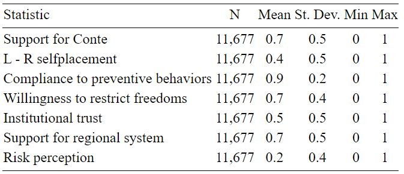

CAN database, descriptives

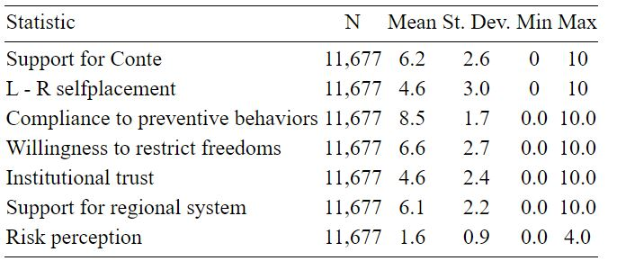

*mgm* database, descriptives

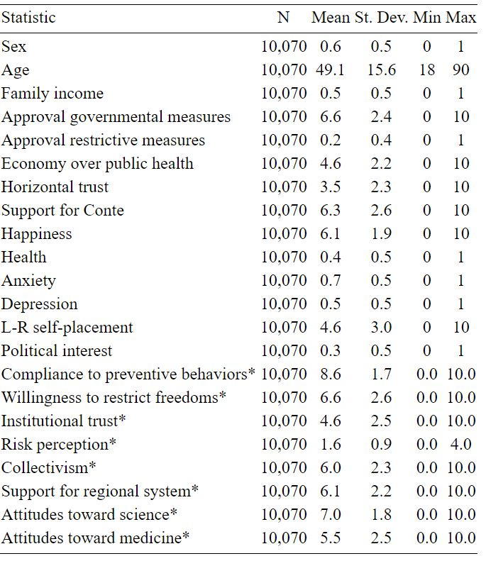

Extendend *mgm* database, descriptives